# analysis

Mikey Elmers

12/06/2022

## Overview

This document investigates the influence of pause-internal particles (PINTs) on recall in a content-based listening task with material from an English-language university lecture. The following PINTs are investigated in the present study: silence, inhalation noises, exhalation noises, filler particles, and tongue clicks. Participants were asked to listen to audio recordings that were approximately three minutes in length and answer content-based questions. 90 participants were recruited. 45 participants were monolingual speakers of English. The other 45 participants were native speakers of German with English proficiency.

Listeners heard a total of four audio segments, each followed by two questions. Participants were scored based on how many questions they got correct with a maximum possible score of 8. Participants were split into three different groups based upon the condition of the audio. Each participant heard only one condition. The following conditions are investigated:

- original condition which includes unmodified audio
- silence condition where all non-silence PINTs material is replaced with silence (same total duration as original audio)
- no PINTs condition where all PINTs are excised from the audio (shorter duration than other two condition)

### Yale lectures

Lectures taken from [Open Yale Courses](https://oyc.yale.edu).

1. [Langdon Hammer](https://oyc.yale.edu/english/engl-310)
   - Course Number: ENGL 310
   - Course Name: Modern Poetry
   - Sessions: 25

## Dataframe codebook

| Variable Name | Description |
| --- | --- |
| id | subject id number |
| condition | three different experimental conditions (original, silence, no PINTs) |
| total score | subject’s total number of correct answers (max score is 8) |
| age | subject age (in years) |
| ease | how easy or difficult the subject found the speaker (1: very difficult to 5: very easy) |
| edu | subject’s education with 3 levels (high school/equivalent, university, and other) |
| imphear | subject’s self-assessment of hearing impairment |
| interest | how interesting the subject found the speaker (1: very uninteresting to 5: very interesting) |
| L1 | subject’s native language with 2 levels (English or German) |
| notes | subject’s self-assessment of whether they took notes (they were instructed to not take notes) |
| prep | how prepared the subject rated the speaker (1: very unprepared to 5: very prepared) |
| self | subject’s self-assessment of their English proficiency (applicable for the German speakers) |
| test | CEFR test for subject (applicable for the L1 German participants) |

## Load in data

```r
df <- read.csv(here::here("data/final/data_full.csv"))
df_de <- read.csv(here::here("data/final/data_de.csv"))
df_en <- read.csv(here::here("data/final/data_en.csv"))
df_binomial_all <- read.csv(here::here("data/final/data_binomial_all.csv"))
```

One participant from the monolingual English group reported hearing impairment and was removed from the analysis.

```r
# remove participant with hearing impairment
df <- df %>% filter(imphear == "no")
df_en <- df_en %>% filter(imphear == "no")
df_binomial_all <- df_binomial_all %>% filter(imphear == "no")
```

Convert variables to factor.

```r
df$id <- as.factor(df$id)
df$condition <- as.factor(df$condition)
df$L1 <- as.factor(df$L1)

df_de$id <- as.factor(df_de$id)
df_de$condition <- as.factor(df_de$condition)
df_de$L1 <- as.factor(df_de$L1)

df_en$id <- as.factor(df_en$id)
df_en$condition <- as.factor(df_en$condition)
df_en$L1 <- as.factor(df_en$L1)
```

## All participants

Mean, median, and standard deviation for total score.

```r
df %>%
  summarize(mean_all = mean(total_score),
            median_all = median(total_score),
            sd_all = sd(total_score),
            N = n())
```

```
##   mean_all median_all   sd_all  N
## 1 5.955056          6 1.573286 89
```

## L1 comparison

The monolingual English participants have a higher mean total score than the L1 German participants. However, the difference between L1 for mean total score is not significant.

```r
df %>%
  group_by(L1) %>%
  summarize(mean = mean(total_score),
            median = median(total_score),
            sd = sd(total_score),
            N = n()) %>%
  ungroup()
```

```
## # A tibble: 2 × 5
##   L1     mean median    sd     N
##   <fct> <dbl>  <dbl> <dbl> <int>
## 1 eng    6.07      6  1.73    44
## 2 ger    5.84      6  1.41    45
```

```r
# normality is violated
# H0: The samples come from a normal distribution
# H1: The samples do not come from a normal distribution
# p-value < 0.05 (data deviates from normality)
shapiro.test(df$total_score)
```

```
##
##  Shapiro-Wilk normality test
##
## data:  df$total_score
## W = 0.9109, p-value = 1.424e-05
```

```r
# homogeneity of variances is maintained across L1
# H0: variances are equal
# H1: variances are not equal
# p-value > 0.05 (variances are not significantly different between groups)
leveneTest(total_score ~ L1, data = df)
```

```
## Levene's Test for Homogeneity of Variance (center = median)
##       Df F value Pr(>F)
## group  1  1.0285 0.3133
##       87
```

```r
# t-test
# since the central limit theorem is satisfied (n > 30) we will still proceed with parametric tests.
t.test(df_en$total_score, df_de$total_score, var.equal = TRUE)
```

```
##
##  Two Sample t-test
##
## data:  df_en$total_score and df_de$total_score
## t = 0.66865, df = 87, p-value = 0.5055
## alternative hypothesis: true difference in means is not equal to 0
## 95 percent confidence interval:
##  -0.4413361  0.8888108
## sample estimates:
## mean of x mean of y
##  6.068182  5.844444
```

```r
# cohen's d
cohen.d(df_en$total_score, df_de$total_score)
```

```
##
## Cohen's d
##
## d estimate: 0.1417627 (negligible)
## 95 percent confidence interval:
##      lower      upper
## -0.2801649  0.5636904
```

## Condition comparison

The no PINTs condition has the highest mean total score, while the silence condition has the lowest mean total score. However, an ANOVA shows that there are not significant differences between the conditions when predicting total score.

```r
df %>%
  group_by(condition) %>%
  summarize(mean = mean(total_score),
            median = median(total_score),
            sd = sd(total_score),
            N = n()) %>%
  arrange(desc(mean)) %>%
  ungroup()
```

```
## # A tibble: 3 × 5
##   condition  mean median    sd     N
##   <fct>     <dbl>  <dbl> <dbl> <int>
## 1 nopints    6.07    6.5  1.62    30
## 2 original   5.94    6    1.55    31
## 3 silence    5.86    6    1.60    28
```

```r
# normality is violated
# H0: The samples come from a normal distribution
# H1: The samples do not come from a normal distribution
# p-value < 0.05 (data deviates from normality)
shapiro.test(df$total_score)
```

```
##
##  Shapiro-Wilk normality test
##
## data:  df$total_score
## W = 0.9109, p-value = 1.424e-05
```

```r
# homogeneity of variances is maintained across conditions
# H0: variances are equal
# H1: variances are not equal
# p-value > 0.05 (variances are not significantly different between groups)
leveneTest(total_score ~ condition, data = df)
```

```
## Levene's Test for Homogeneity of Variance (center = median)
##       Df F value Pr(>F)
## group  2  0.2323 0.7932
##       86
```

```r
# anova for each condition
summary(aov(total_score ~ condition, data = df))
```

```
##             Df Sum Sq Mean Sq F value Pr(>F)
## condition    2   0.65   0.327   0.129  0.879
## Residuals   86 217.17   2.525
```

## Total Score Visualization

The boxplots and density plots show the distributions of total score based on condition and first language. These visualizations reinforce that there is not significant differences between condition or L1 when predicting a participant’s total score.

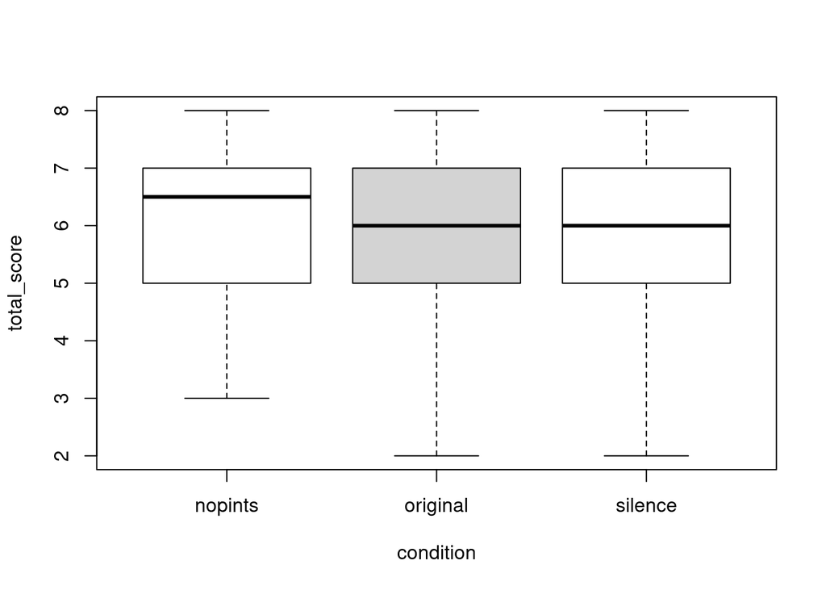

```r
# Boxplot
boxplot(total_score ~ condition, col=c("white","lightgray"), data = df)
```

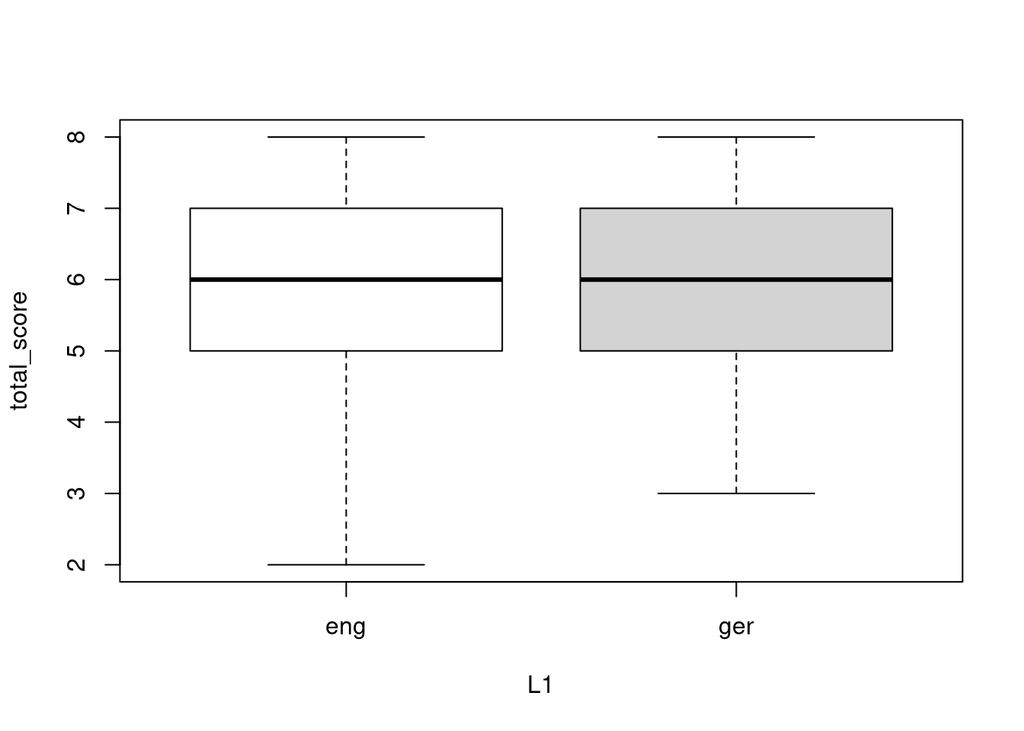

```r
boxplot(total_score ~ L1, col=c("white","lightgray"), data = df)
```

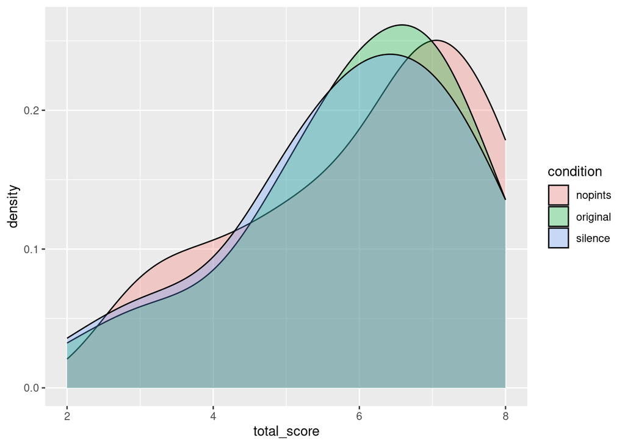

```r
# Density Plot
ggplot(data = df, aes(x = total_score, fill = condition)) +
  geom_density(alpha = 0.3)
```

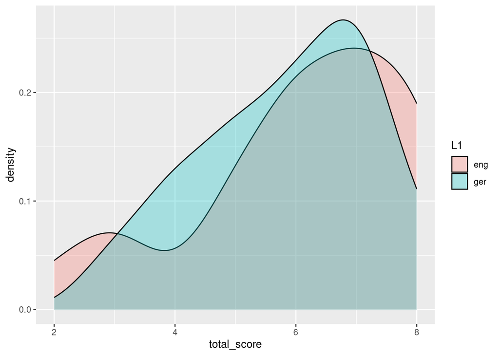

```r
ggplot(data = df, aes(x = total_score, fill = L1)) +
  geom_density(alpha = 0.3)
```

## Condition and L1 comparison

Here we find that monolingual English participants scored better than the L1 German participants except for the original condition. Monolingual English participants performed best with the no PINTs condition while the L1 German participants performed best with the original audio condition.

```r
df %>%
  group_by(condition, L1) %>%
  summarize(mean = mean(total_score),
            median = median(total_score),
            sd = sd(total_score),
            N = n()) %>%
  arrange(desc(mean)) %>%
  ungroup()
```

```
## # A tibble: 6 × 6
##   condition L1     mean median    sd     N
##   <fct>     <fct> <dbl>  <dbl> <dbl> <int>
## 1 nopints   eng    6.27      7  1.83    15
## 2 silence   eng    6.08      6  1.44    13
## 3 original  ger    6         6  1.07    15
## 4 original  eng    5.88      6  1.93    16
## 5 nopints   ger    5.87      6  1.41    15
## 6 silence   ger    5.67      5  1.76    15
```

## Precede - original and silence condition

Convert variable to factor.

```r
df_binomial_all$precede <- as.factor(df_binomial_all$precede)
```

Participants performed significantly better when critical information was NOT preceded by PINTs information.

```r
df_binomial_all %>%
  group_by(precede) %>%
  summarize(mean = mean(score),
            median = median(score),
            sd = sd(score),
            count = sum(score == 1),
            N = n()) %>%
  arrange(desc(mean)) %>%
  ungroup()
```

```
## # A tibble: 2 × 6
##   precede  mean median    sd count     N
##   <fct>   <dbl>  <dbl> <dbl> <int> <int>
## 1 no      0.814      1 0.390   192   236
## 2 yes     0.661      1 0.474   156   236
```

```r
# normality is violated
# H0: The samples come from a normal distribution
# H1: The samples do not come from a normal distribution
# p-value < 0.05 (data deviates from normality)
shapiro.test(df_binomial_all$score)
```

```
##
##  Shapiro-Wilk normality test
##
## data:  df_binomial_all$score
## W = 0.54887, p-value < 2.2e-16
```

```r
# homogeneity of variances is maintained across L1
# H0: variances are equal
# H1: variances are not equal
# p-value < 0.05 (variances are significantly different between groups)
leveneTest(score ~ precede, data = df_binomial_all)
```

```
## Levene's Test for Homogeneity of Variance (center = median)
##        Df F value    Pr(>F)
## group   1  14.553 0.0001545 ***
##       470
## ---
## Signif. codes:  0 '***' 0.001 '**' 0.01 '*' 0.05 '.' 0.1 ' ' 1
```

```r
# Wilcoxon rank-sum test
# since both normality and equal variances is violated a non-parametric test is used
precede_yes_group <- subset(df_binomial_all, precede == "yes")
precede_no_group <- subset(df_binomial_all, precede == "no")
wilcox.test(precede_no_group$score, precede_yes_group$score)
```

```
##
##  Wilcoxon rank sum test with continuity correction
##
## data:  precede_no_group$score and precede_yes_group$score
## W = 32096, p-value = 0.0001695
## alternative hypothesis: true location shift is not equal to 0
```

## Correlation

When looking at correlations for participant’s total score we see that the age and interest of the participant have no correlation with total score. The correlations between ease of listening and perceived preparedness of the speaker are significant and weakly correlated with total score.

```r
df_cor <- df[, c(3,4,5,8,11)]
cor(df_cor)
```

```
##             total_score         age        ease   interest       prep
## total_score  1.00000000  0.09343636  0.30473922 0.09836165 0.28455646
## age          0.09343636  1.00000000 -0.07974169 0.14811576 0.04303631
## ease         0.30473922 -0.07974169  1.00000000 0.41905032 0.66591067
## interest     0.09836165  0.14811576  0.41905032 1.00000000 0.54381969
## prep         0.28455646  0.04303631  0.66591067 0.54381969 1.00000000
```

```r
cor.test(df_cor$total_score, df_cor$ease)
```

```
##
##  Pearson's product-moment correlation
##
## data:  df_cor$total_score and df_cor$ease
## t = 2.9844, df = 87, p-value = 0.003688
## alternative hypothesis: true correlation is not equal to 0
## 95 percent confidence interval:
##  0.1030206 0.4823821
## sample estimates:
##       cor
## 0.3047392
```

```r
cor.test(df_cor$total_score, df_cor$prep)
```

```
##
##  Pearson's product-moment correlation
##
## data:  df_cor$total_score and df_cor$prep
## t = 2.7686, df = 87, p-value = 0.006879
## alternative hypothesis: true correlation is not equal to 0
## 95 percent confidence interval:
##  0.08110614 0.46524255
## sample estimates:
##       cor
## 0.2845565
```

## Ease

Participant’s reported how easy it was to follow/understand the speaker (1: very difficult and 5: very easy). Overall, the mean ease is 2.82.

```r
# ease score in general
df %>%
  summarize(mean_ease = mean(ease),
            median_ease = median(ease),
            sd_ease = sd(ease))
```

```
##   mean_ease median_ease  sd_ease
## 1  2.820225           3 1.239151
```

## Ease by L1

When grouping ease by L1 we find that monolingual English listeners overall found the speaker easier to understand than the L1 German listeners. However, the difference is not statistically significant

```r
# ease per L1
df %>%
  group_by(L1) %>%
  summarize(mean_ease = mean(ease),
            sd_ease = sd(ease)) %>%
  arrange(desc(mean_ease)) %>%
  ungroup()
```

```
## # A tibble: 2 × 3
##   L1    mean_ease sd_ease
##   <fct>     <dbl>   <dbl>
## 1 eng        3.05    1.29
## 2 ger        2.6     1.16
```

```r
# normality is violated
# H0: The samples come from a normal distribution
# H1: The samples do not come from a normal distribution
# p-value < 0.05 (data deviates from normality)
shapiro.test(df$ease)
```

```
##
##  Shapiro-Wilk normality test
##
## data:  df$ease
## W = 0.90463, p-value = 7.285e-06
```

```r
# homogeneity of variances is maintained across L1
# H0: variances are equal
# H1: variances are not equal
# p-value > 0.05 (variances are not significantly different between groups)
leveneTest(ease ~ L1, data = df)
```

```
## Levene's Test for Homogeneity of Variance (center = median)
##       Df F value Pr(>F)
## group  1  0.6622  0.418
##       87
```

```r
# t-test
# since the central limit theorem is satisfied (n > 30) we will still proceed with parametric tests.
t.test(df_en$ease, df_de$ease, var.equal = TRUE)
```

```
##
##  Two Sample t-test
##
## data:  df_en$ease and df_de$ease
## t = 1.7141, df = 87, p-value = 0.09006
## alternative hypothesis: true difference in means is not equal to 0
## 95 percent confidence interval:
##  -0.07106466  0.96197375
## sample estimates:
## mean of x mean of y
##  3.045455  2.600000
```

```r
# cohen's d
cohen.d(df_en$ease, df_de$ease)
```

```
##
## Cohen's d
##
## d estimate: 0.3634211 (small)
## 95 percent confidence interval:
##       lower       upper
## -0.06144146  0.78828364
```

## Ease by condtion

When grouping by condition we found that the condition that removed all the pause material was considered the easiest to follow. However, the differences between condition were not statistically significant. This finding is nonetheless interesting since deleting this material created artifacts within the audio. The original, unmanipulated version was found to be the most difficult to follow, possibly because this speaker uses a high frequency of PINTs (~40% of their total speaking time).

```r
# ease per condition
df %>%
  group_by(condition) %>%
  summarize(mean_ease = mean(ease)) %>%
  arrange(desc(mean_ease)) %>%
  ungroup()
```

```
## # A tibble: 3 × 2
##   condition mean_ease
##   <fct>         <dbl>
## 1 nopints        3.03
## 2 silence        2.82
## 3 original       2.61
```

```r
# normality is violated
# H0: The samples come from a normal distribution
# H1: The samples do not come from a normal distribution
# p-value < 0.05 (data deviates from normality)
shapiro.test(df$ease)
```

```
##
##  Shapiro-Wilk normality test
##
## data:  df$ease
## W = 0.90463, p-value = 7.285e-06
```

```r
# homogeneity of variances is maintained across conditions
# H0: variances are equal
# H1: variances are not equal
# p-value > 0.05 (variances are not significantly different between groups)
leveneTest(ease ~ condition, data = df)
```

```
## Levene's Test for Homogeneity of Variance (center = median)
##       Df F value Pr(>F)
## group  2   0.592 0.5555
##       86
```

```r
# anova for each condition
summary(aov(ease ~ condition, data = df))
```

```
##             Df Sum Sq Mean Sq F value Pr(>F)
## condition    2   2.69   1.347   0.875  0.421
## Residuals   86 132.43   1.540
```

## Ease grouped by condition and L1

When looking at ease grouped by both condition and L1 we find some interesting trends. The monolingual English listeners find the version without PINTs to be the easiest while the L1 German listeners find the original, unmodified version, to be the easiest to follow. Overall, this indicates the complex confluence of factors that effect the ease of listening.

```r
# ease grouped by condition and L1
df %>%
  group_by(condition, L1) %>%
  summarize(mean_ease = mean(ease)) %>%
  arrange(desc(mean_ease)) %>%
  ungroup()
```

```
## # A tibble: 6 × 3
##   condition L1    mean_ease
##   <fct>     <fct>     <dbl>
## 1 nopints   eng        3.47
## 2 silence   eng        3.15
## 3 original  ger        2.67
## 4 nopints   ger        2.6
## 5 original  eng        2.56
## 6 silence   ger        2.53
```

## Modeling

Converting variables to factors.

```r
# convert to factors
df$ease <- as.factor(df$ease)
df$prep <- as.factor(df$prep)
df$edu <- as.factor(df$edu)
df$self <- as.factor(df$self)
df$test <- as.factor(df$test)

df_de$ease <- as.factor(df_de$ease)
df_de$prep <- as.factor(df_de$prep)
df_de$edu <- as.factor(df_de$edu)
df_de$self <- as.factor(df_de$self)
df_de$test <- as.factor(df_de$test)

df_en$ease <- as.factor(df_en$ease)
df_en$prep <- as.factor(df_en$prep)
df_en$edu <- as.factor(df_en$edu)
df_en$self <- as.factor(df_en$self)
df_en$test <- as.factor(df_en$test)

df_binomial_all$id <- as.factor(df_binomial_all$id)
df_binomial_all$condition <- as.factor(df_binomial_all$condition)
df_binomial_all$ease <- as.factor(df_binomial_all$ease)
df_binomial_all$prep <- as.factor(df_binomial_all$prep)
df_binomial_all$edu <- as.factor(df_binomial_all$edu)
df_binomial_all$L1 <- as.factor(df_binomial_all$L1)
df_binomial_all$self <- as.factor(df_binomial_all$self)
df_binomial_all$test <- as.factor(df_binomial_all$test)
df_binomial_all$question <- as.factor(df_binomial_all$question)
```

### Linear Regression: All data

#### Checking assumption

The shapiro test indicates that our data does not come a normal distribution. Since the central limit theorem is satisfied (n > 30) we will still proceed with parametric tests.

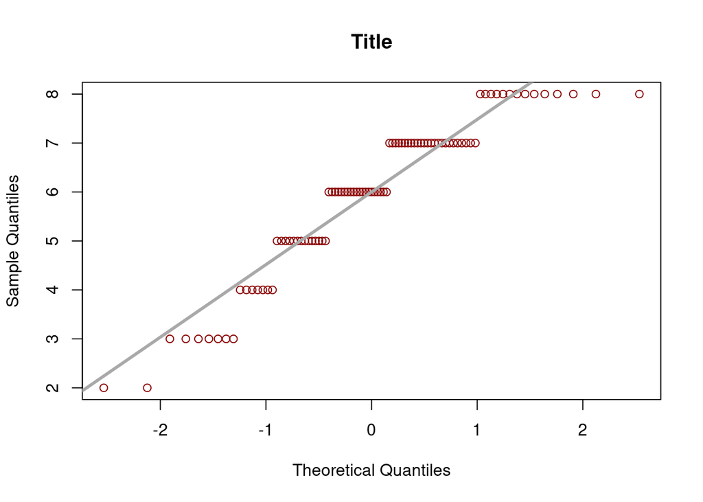

```r
# Checking Assumptions
qqnorm(df$total_score, col = "darkred", main = "Title")
qqline(df$total_score, col = "darkgrey", lwd = 3)
```

```r
# H0: The samples come from a normal distribution
# H1: The samples do not come from a normal distribution
# p-value < .05.Data deviates from normality
shapiro.test(df$total_score)
```

```
##
##  Shapiro-Wilk normality test
##
## data:  df$total_score
## W = 0.9109, p-value = 1.424e-05
```

#### Model information

Linear regression models were tested, with interaction between fixed effects producing a worse fit. Linear regression was chosen because there was only a single data point per participant so it wasn’t possible to have participant as a random effect. The model with best fit (lowest AIC score) is the model which predicts total score with ease as the only fixed effect. Looking at the summary we find significant effects for ease2, ease4, and ease5. This indicates that the easier the participants found the speaker the higher their total score. Importantly, an ease score of 5 improves the score more than an ease score of 4 which improves more than ease score of 2. Only the ease score of 3 does not follow this trend. A possible explanation is that the participants who didn’t have strong feelings in either direction might have selected the middle score.

```r
model0 <- lm(total_score ~ condition, data = df)
model1 <- lm(total_score ~ L1, data = df)
model2 <- lm(total_score ~ ease, data = df)
model3 <- lm(total_score ~ prep, data = df)
AIC(model0, model1, model2, model3)
```

```
##        df      AIC
## model0  4 339.9614
## model1  3 337.7729
## model2  6 332.4276
## model3  6 334.7345
```

```r
summary(model2)
```

```
##
## Call:
## lm(formula = total_score ~ ease, data = df)
##
## Residuals:
##     Min      1Q  Median      3Q     Max
## -4.3889 -0.8000  0.1538  1.0000  3.1538
##
## Coefficients:
##             Estimate Std. Error t value Pr(>|t|)
## (Intercept)   4.8462     0.4180  11.595  < 2e-16 ***
## ease2         1.1538     0.5058   2.281  0.02506 *
## ease3         0.9538     0.5369   1.777  0.07925 .
## ease4         1.5427     0.5485   2.813  0.00612 **
## ease5         1.9538     0.6339   3.082  0.00278 **
## ---
## Signif. codes:  0 '***' 0.001 '**' 0.01 '*' 0.05 '.' 0.1 ' ' 1
##
## Residual standard error: 1.507 on 84 degrees of freedom
## Multiple R-squared:  0.1242, Adjusted R-squared:  0.08248
## F-statistic: 2.978 on 4 and 84 DF,  p-value: 0.0237
```

### Binomial Models: All Data

#### Checking assumption

The shapiro test indicates that our data does not come a normal distribution. Since the central limit theorem is satisfied (n > 30) we will still proceed with parametric tests.

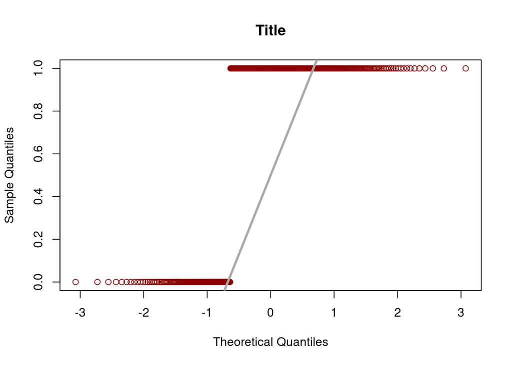

```r
# Checking Assumptions
qqnorm(df_binomial_all$score, col = "darkred", main = "Title")
qqline(df_binomial_all$score, col = "darkgrey", lwd = 3)
```

```r
# H0: The samples come from a normal distribution
# H1: The samples do not come from a normal distribution
# p-value < .05.Data deviates from normality
shapiro.test(df_binomial_all$score)
```

```
##
##  Shapiro-Wilk normality test
##
## data:  df_binomial_all$score
## W = 0.54887, p-value < 2.2e-16
```

#### Model information

Binomial generalized linear mixed models (binomial GLMMs) were tested. Models with interaction between fixed effects produced a worse fit. The model with best fit (lowest AIC score) is the model which predicts score (by-question) with precede as the only fixed effect and subject id with intercept as a random effect. We found a significant effect for precedeyes with the estimate representing the log-odds ratio of a positive score when the critical information is preceded by PINTs (compared to when the critical information is not preceded by PINTs). Simply, when critical information for the question is preceded by PINTs, then the participant was more likely to get the question wrong.

```r
model_binomial0 <- glmer(score ~ L1 + (1 | id), data = df_binomial_all, family = binomial)
model_binomial1 <- glmer(score ~ condition + (1 | id), data = df_binomial_all, family = binomial)
model_binomial2 <- glmer(score ~ precede + (1 | id), data = df_binomial_all, family = binomial)
model_binomial3 <- glmer(score ~ ease + (1 | id), data = df_binomial_all, family = binomial)
model_binomial4 <- glmer(score ~ prep + (1 | id), data = df_binomial_all, family = binomial)
AIC(model_binomial0, model_binomial1, model_binomial2, model_binomial3, model_binomial4)
```

```
##                 df      AIC
## model_binomial0  3 542.3664
## model_binomial1  3 542.4670
## model_binomial2  3 526.9560
## model_binomial3  6 542.1024
## model_binomial4  6 543.2696
```

```r
summary(model_binomial2)
```

```
## Generalized linear mixed model fit by maximum likelihood (Laplace
##   Approximation) [glmerMod]
##  Family: binomial  ( logit )
## Formula: score ~ precede + (1 | id)
##    Data: df_binomial_all
##
##      AIC      BIC   logLik deviance df.resid
##    527.0    539.4   -260.5    521.0      469
##
## Scaled residuals:
##     Min      1Q  Median      3Q     Max
## -2.5795 -0.8523  0.4484  0.6010  1.1733
##
## Random effects:
##  Groups Name        Variance Std.Dev.
##  id     (Intercept) 0.4762   0.6901
## Number of obs: 472, groups:  id, 59
##
## Fixed effects:
##             Estimate Std. Error z value Pr(>|z|)
## (Intercept)   1.6171     0.2038   7.936 2.09e-15 ***
## precedeyes   -0.8767     0.2263  -3.874 0.000107 ***
## ---
## Signif. codes:  0 '***' 0.001 '**' 0.01 '*' 0.05 '.' 0.1 ' ' 1
##
## Correlation of Fixed Effects:
##            (Intr)
## precedeyes -0.683
```